# Homework 3

2022-04-20

1. Read in the ities.csv datafile as a dataframe object, df.

```r
df <- read.csv('ities.csv'
               , stringsAsFactors = T)  #read in the dataframe and name it as df
```

2. (1 point) Display the number of rows and columns in the dataset using an appropriate R function. Below the output, identify which numbers from the output correspond to the number of rows and columns.

```r
nrow(df)                               # df rows
```

```
## [1] 438151
```

```r
ncol(df)                               # df columns
```

```
## [1] 13
```

```r
dim(df)                                # df rows x columns
```

```
## [1] 438151     13
```

**dim(df) = rows x columns**

3. (1 point) Display the structure of the dataframe, df. Below the output, briefly summarize two main points about the dataframe structure.

```r
#Displaying the structure of the dataframe
str(df)
```

```
## 'data.frame':    438151 obs. of  13 variables:
##  $ Date             : Factor w/ 1021 levels "1/1/2015","1/1/2016",..: 809 809 809 809 809 809 809 809 809 809 ...
##  $ OperationType    : Factor w/ 2 levels "RETURN","SALE": 2 2 2 2 2 2 2 2 2 2 ...
##  $ CashierName      : Factor w/ 56 levels "Aimee Port","Alberta Lynch",..: 54 54 54 54 54 54 54 54 54 54 ...
##  $ LineItem         : Factor w/ 68 levels "Aubergine and Chickpea Vindaloo",..: 53 37 14 53 53 9 22 2 53 37 ...
##  $ Department       : Factor w/ 9 levels "Beverage","Catering",..: 3 1 6 7 7 4 6 3 3 1 ...
##  $ Category         : Factor w/ 21 levels "Aubergine and Chickpea Vindaloo",..: 20 10 2 11 11 11 6 3 20 10 ...
##  $ RegisterName     : Factor w/ 12 levels "FT136","FT137",..: 10 10 10 10 10 10 10 10 10 10 ...
##  $ StoreNumber      : Factor w/ 70 levels "AZ23501251","AZ23501258",..: 5 4 11 22 22 23 8 2 5 4 ...
##  $ TransactionNumber: Factor w/ 161058 levels "00002G3137186",..: 12864 12864 113176 156622 156622 29277 5295 147148 147148 147148 ...
##  $ CustomerCode     : Factor w/ 9110 levels "C0010348848",..: 8245 8245 8245 8245 8245 8245 8245 8245 8245 8245 ...
##  $ Price            : num  66.22 2.88 12.02 18.43 18.43 ...
##  $ Quantity         : int  1 1 2 1 1 1 1 1 1 1 ...
##  $ TotalDue         : num  66.22 2.88 24.04 18.43 18.43 ...
```

**Brief Summary of Two Main Points**

*1. This data frame structure summarizes single transaction on each row with 13 different columns or variables ranging from Date to Total Due.*

*2. This data frame structure could be reorganized to better structure. For examples, category and line item are very similar to each other or identical in some cases. They could be separated or combined to better organize the data.*

4. (2 points) Display a summary of the columns in df. Below the output, comment on at least two columns for which the existing data type is not useful for the summary function, the format to which they should be changed, and why that change would be helpful.*

```r
#summry of the columns in df (chr to fctr).
summary(df)
```

```
##          Date        OperationType            CashierName
##  9/20/2014 :  1056   RETURN:   349   Wallace Kuiper : 79328
##  10/17/2014:   920   SALE  :437802   Irving Burgos  : 25015
##  9/12/2015 :   910                   Diana Miller   : 24869
##  3/29/2014 :   903                   Rachael Price  : 24346
##  2/28/2014 :   887                   Vincent Ball   : 23552
##  10/9/2015 :   864                   Stephanie Raven: 20728
##  (Other)   :432611                   (Other)        :240313
##                         LineItem         Department
##  Salmon and Wheat Bran Salad: 89051   Entrees :152575
##  Chicken and Onion Kabob    : 51362   Kabobs  :102053
##  Beef and Squash Kabob      : 34748   Sides   : 97284
##  Yogurt                     : 33203   Beverage: 35746
##  Beef and Apple Burgers     : 32246   general : 27885
##  Fountain Drink             : 29390   Salad   : 20870
##  (Other)                    :168151   (Other) :  1738
##                         Category       RegisterName        StoreNumber
##  Salmon and Wheat Bran Salad: 72601   RT149  :160786   AZ23501305: 72601
##  Chicken                    : 51362   RT147  :109264   AZ23501336: 51362
##  general                    : 49516   RT145  : 67648   AZ23501367: 34748
##  Beef                       : 34748   RT135  : 24999   AZ23501596: 33203
##  Yogurt                     : 33203   RT146  : 21145   AZ23501258: 32246
##  Beef and Apple Burgers     : 32246   RT151  : 20092   AZ23501289: 29390
##  (Other)                    :164475   (Other): 34217   (Other)   :184601
##      TransactionNumber       CustomerCode        Price
##  00XHLAF147696:    64   CWM11331L8O:393645   Min.   :-5740.51
##  00QG7IM183127:    45   CNJ6039IN9 :   162   1st Qu.:    4.50
##  00HIKMB68419 :    42   CJ04273UTK :    82   Median :   11.29
##  00N79DD84626 :    40   C9E3494ICE :    75   Mean   :   14.36
##  00SMJ8R148203:    39   C5D11136WBI:    72   3rd Qu.:   14.68
##  009DZG9134033:    37   CZW6572NTE :    68   Max.   :21449.97
##  (Other)      :437884   (Other)    : 44047   NA's   :12
##     Quantity          TotalDue
##  Min.   :  1.000   Min.   :-5740.51
##  1st Qu.:  1.000   1st Qu.:    4.50
##  Median :  1.000   Median :   11.80
##  Mean   :  1.177   Mean   :   15.26
##  3rd Qu.:  1.000   3rd Qu.:   15.04
##  Max.   :815.000   Max.   :21449.97
##                    NA's   :12
```

*1. The dataframe’s default data type was character from Date to CustomerCode. Which showed the character as the column summary. Converting the data type to factors made the data frame structure more helpful to interpret and analyze the data.*

*2. The columns RegisterName, StoreNumber and CustomerCode could be improved by changing to what it represent such as actual location (Factors), simplified store number (Factors), interpretation of customer code (Factors). The data dictionary does not cover the comprehensive meaning of the each code and number to make it helpful for analysis.*

5. (3 points) Convert the values in Department and LineItem columns to lower case and save them as new columns, Department_lower and LineItem_lower. Display the first five rows of only those four columns, Department, Department_lower, LineItem, and LineItem_lower to verify that the case conversion worked.

```r
#install.packages('stringr')
library(stringr)

#Creating new lower chase columns in df for columns Department & LineItem.
df$Department_lower <- str_to_lower(df$Department)
df$LineItem_lower <- str_to_lower(df$LineItem)

#Confirmation Display for the lower case conversions.
df[1:5, c('Department', 'Department_lower', 'LineItem', 'LineItem_lower')]
```

```
##   Department Department_lower                    LineItem
## 1    Entrees          entrees Salmon and Wheat Bran Salad
## 2   Beverage         beverage              Fountain Drink
## 3     Kabobs           kabobs       Beef and Squash Kabob
## 4      Salad            salad Salmon and Wheat Bran Salad
## 5      Salad            salad Salmon and Wheat Bran Salad
##                LineItem_lower
## 1 salmon and wheat bran salad
## 2              fountain drink
## 3       beef and squash kabob
## 4 salmon and wheat bran salad
## 5 salmon and wheat bran salad
```

6. (2 points) Use the “plot” function on Department_lower, and then run that code chunk. You will get an error. Below the output, describe the reason for the error. Then make sure and comment out this code chunk by placing a hashtag/pound sign on the far left of the line of code. If you don’t comment out code that contains an error, then the markdown file will not be able to knit to an html file.

*The Department_lower’s data type is character. Therefore, when we try to plot the data, it cannot plot unless we convert the character types to factors.*

7. (3 points) Convert the datatype of Department_lower to a factor type. Do not create a new column, just convert it in place. Display the structure of the dataframe, df, to verify that the Department_lower column is a factor data type. Beneath the output, indicate how many levels there are in the Department_lower column.

```r
df$Department_lower <- factor(df$Department_lower)
str(df)
```

```
## 'data.frame':    438151 obs. of  15 variables:
##  $ Date             : Factor w/ 1021 levels "1/1/2015","1/1/2016",..: 809 809 809 809 809 809 809 809 809 809 ...
##  $ OperationType    : Factor w/ 2 levels "RETURN","SALE": 2 2 2 2 2 2 2 2 2 2 ...
##  $ CashierName      : Factor w/ 56 levels "Aimee Port","Alberta Lynch",..: 54 54 54 54 54 54 54 54 54 54 ...
##  $ LineItem         : Factor w/ 68 levels "Aubergine and Chickpea Vindaloo",..: 53 37 14 53 53 9 22 2 53 37 ...
##  $ Department       : Factor w/ 9 levels "Beverage","Catering",..: 3 1 6 7 7 4 6 3 3 1 ...
##  $ Category         : Factor w/ 21 levels "Aubergine and Chickpea Vindaloo",..: 20 10 2 11 11 11 6 3 20 10 ...
##  $ RegisterName     : Factor w/ 12 levels "FT136","FT137",..: 10 10 10 10 10 10 10 10 10 10 ...
##  $ StoreNumber      : Factor w/ 70 levels "AZ23501251","AZ23501258",..: 5 4 11 22 22 23 8 2 5 4 ...
##  $ TransactionNumber: Factor w/ 161058 levels "00002G3137186",..: 12864 12864 113176 156622 156622 29277 5295 147148 147148 147148 ...
##  $ CustomerCode     : Factor w/ 9110 levels "C0010348848",..: 8245 8245 8245 8245 8245 8245 8245 8245 8245 8245 ...
##  $ Price            : num  66.22 2.88 12.02 18.43 18.43 ...
##  $ Quantity         : int  1 1 2 1 1 1 1 1 1 1 ...
##  $ TotalDue         : num  66.22 2.88 24.04 18.43 18.43 ...
##  $ Department_lower : Factor w/ 9 levels "beverage","catering",..: 3 1 6 7 7 4 6 3 3 1 ...
##  $ LineItem_lower   : chr  "salmon and wheat bran salad" "fountain drink" "beef and squash kabob" "salmon and wheat bran salad" ...
```

*As shown above, there are 9 levels in the Department_lower column.*

8. (5 points) Use the “plot” function on the Department_lower column to display a plot of that column from most frequent on the left to least frequent on the right. Below the output, identify the department that occurs most frequently, as well as the one that occurs least frequently.
9. It may be hard for you to read the names of all of the departments from the plot. You may have to add additional code to adjust the plot or to print out additional summary information so that you can identify the Departments that appear most/least frequently. Make sure that your comments are supported by the code that is displayed.

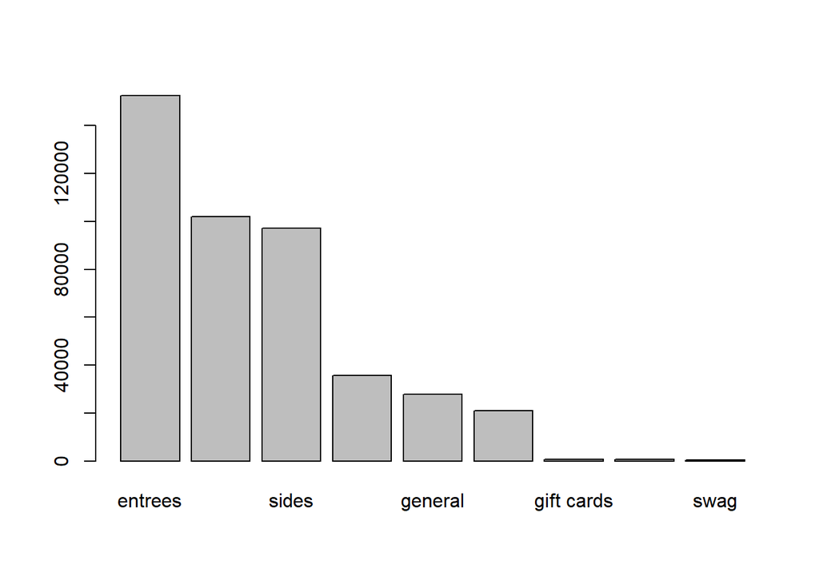

```r
#installing forcats to utilize the function to reorder the dataframe with ease.
#install.packages('forcats')
library(forcats)

#converting Department_lower to display from most frequent on the left to least frequent on the right with 9 levels of departments including others.
df$Department_lower <- fct_infreq(fct_lump(df$Department_lower, n = 9))
plot(df$Department_lower)
```